# introduction

Edzer Pebesma

**For a better version of the stars vignettes see** https://r-spatial.github.io/stars/articles/

Package `stars` provides infrastructure for *data cubes*, array data with labeled dimensions, with emphasis on arrays where some of the dimensions relate to time and/or space.

Spatial data cubes are arrays with one or more spatial dimensions. Raster data cubes have at least two spatial dimensions that form the raster tesselation. Vector data cubes have at least one spatial dimension that may for instance reflect a polygon tesselation, or a set of point locations. Conversions between the two (rasterization, polygonization) are provided. Vector data are represented by simple feature geometries (packages `sf`). Tidyverse methods are provided.

The `stars` package is loaded by

```r
library(stars)
## Loading required package: abind
## Loading required package: sf
## Linking to GEOS 3.8.0, GDAL 3.0.4, PROJ 7.0.0
```

Spatiotemporal arrays are stored in objects of class `stars`; methods for class `stars` currently available are

```r
methods(class = "stars")
##  [1] $<-               Math              Ops               [
##  [5] [<-               adrop             aggregate         aperm
##  [9] as.data.frame     c                 coerce            contour
## [13] cut               dim               dimnames          dimnames<-
## [17] droplevels        image             initialize        is.na
## [21] merge             plot              predict           print
## [25] show              slotsFromS3       split             st_apply
## [29] st_area           st_as_sf          st_as_sfc         st_as_stars
## [33] st_bbox           st_coordinates    st_crop           st_crs
## [37] st_crs<-          st_dimensions     st_geometry       st_interpolate_aw
## [41] st_intersects     st_join           st_mosaic         st_normalize
## [45] st_redimension    st_sample         st_transform      st_transform_proj
## [49] write_stars
## see '?methods' for accessing help and source code
```

(tidyverse methods are only visible after loading package `tidyverse`).

# Reading a satellite image

We can read a satellite image through GDAL, e.g. from a GeoTIFF file in the package:

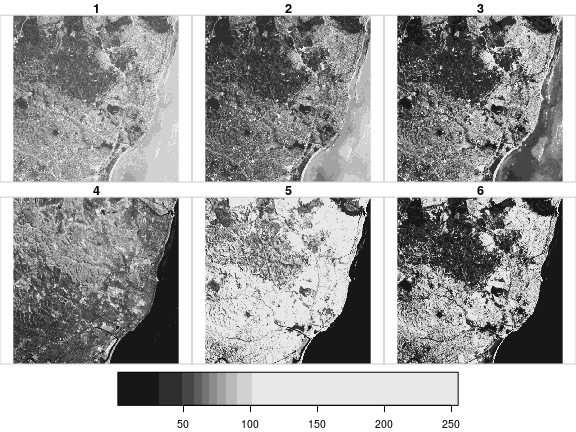

```r
tif = system.file("tif/L7_ETMs.tif", package = "stars")
x = read_stars(tif)
plot(x)
```

We see that the image is geographically referenced (has coordinate values along axes), and that the object returned (`x`) has three dimensions called `x`, `y` and `band`, and has one attribute.

```r
x
## stars object with 3 dimensions and 1 attribute
## attribute(s):
##   L7_ETMs.tif
##  Min.   :  1.00
##  1st Qu.: 54.00
##  Median : 69.00
##  Mean   : 68.91
##  3rd Qu.: 86.00
##  Max.   :255.00
## dimension(s):
##      from  to  offset delta                       refsys point values
## x       1 349  288776  28.5 UTM Zone 25, Southern Hem... FALSE   NULL [x]
## y       1 352 9120761 -28.5 UTM Zone 25, Southern Hem... FALSE   NULL [y]
## band    1   6      NA    NA                           NA    NA   NULL
```

Each dimension has a name; the meaning of the fields of a single dimension are:

| *field* | *meaning* |
| --- | --- |
| from | the origin index (1) |
| to | the final index (dim(x)[i]) |
| offset | the start value for this dimension (pixel boundary), if regular |
| delta | the step (pixel, cell) size for this dimension, if regular |
| refsys | the reference system, or proj4string |
| point | logical; whether cells refer to points, or intervals |
| values | the sequence of values for this dimension (e.g., geometries), if irregular |

This means that for an index i (starting at $i=1$) along a certain dimension, the corresponding dimension value (coordinate, time) is $\mbox{offset} + (i-1) \times \mbox{delta}$. This value then refers to the start (edge) of the cell or interval; in order to get the interval middle or cell centre, one needs to add half an offset.

Dimension `band` is a simple sequence from 1 to 6. Since bands refer to colors, one could put their wavelength values in the `values` field.

`read_stars` reads all bands from a raster dataset, or optionally a subset of raster datasets, into a single `stars` array structure. While doing so, raster values (often UINT8 or UINT16) are converted to double (numeric) values, and scaled back to their original values if needed if the file encodes the scaling parameters.

The data structure `stars` is a generalisation of the `tbl_cube` found in `cubelyr`; we can convert to that by

```r
library(cubelyr)
as.tbl_cube(x)
## Source: local array [737,088 x 3]
## D: x [dbl, 349]
## D: y [dbl, 352]
## D: band [int, 6]
## M: L7_ETMs.tif [dbl[,352,6]]
```

but this will cause a loss of certain properties (cell size, reference system, vector geometries)

## Switching attributes to dimensions and back

```r
(x.spl = split(x, "band"))
## stars object with 2 dimensions and 6 attributes
## attribute(s):
##       X1               X2               X3               X4
##  Min.   : 47.00   Min.   : 32.00   Min.   : 21.00   Min.   :  9.00
##  1st Qu.: 67.00   1st Qu.: 55.00   1st Qu.: 49.00   1st Qu.: 52.00
##  Median : 78.00   Median : 66.00   Median : 63.00   Median : 63.00
##  Mean   : 79.15   Mean   : 67.57   Mean   : 64.36   Mean   : 59.24
##  3rd Qu.: 89.00   3rd Qu.: 79.00   3rd Qu.: 77.00   3rd Qu.: 75.00
##  Max.   :255.00   Max.   :255.00   Max.   :255.00   Max.   :255.00
##       X5               X6
##  Min.   :  1.00   Min.   :  1.00
##  1st Qu.: 63.00   1st Qu.: 32.00
##  Median : 89.00   Median : 60.00
##  Mean   : 83.18   Mean   : 59.98
##  3rd Qu.:112.00   3rd Qu.: 88.00
##  Max.   :255.00   Max.   :255.00
## dimension(s):
##   from  to  offset delta                       refsys point values
## x    1 349  288776  28.5 UTM Zone 25, Southern Hem... FALSE   NULL [x]
## y    1 352 9120761 -28.5 UTM Zone 25, Southern Hem... FALSE   NULL [y]
merge(x.spl)
## stars object with 3 dimensions and 1 attribute
## attribute(s):
##        X
##  Min.   :  1.00
##  1st Qu.: 54.00
##  Median : 69.00
##  Mean   : 68.91
##  3rd Qu.: 86.00
##  Max.   :255.00
## dimension(s):
##    from  to  offset delta                       refsys point    values
## x     1 349  288776  28.5 UTM Zone 25, Southern Hem... FALSE      NULL [x]
## y     1 352 9120761 -28.5 UTM Zone 25, Southern Hem... FALSE      NULL [y]
## X1    1   6      NA    NA                           NA    NA X1,...,X6
```

We see that the newly created dimension lost its name, and the single attribute got a default name. We can set attribute names with `setNames`, and dimension names and values with `st_set_dimensions`:

```r
merge(x.spl) %>%
  setNames(names(x)) %>%
  st_set_dimensions(3, values = paste0("band", 1:6)) %>%
  st_set_dimensions(names = c("x", "y", "band"))
## stars object with 3 dimensions and 1 attribute
## attribute(s):
##   L7_ETMs.tif
##  Min.   :  1.00
##  1st Qu.: 54.00
##  Median : 69.00
##  Mean   : 68.91
##  3rd Qu.: 86.00
##  Max.   :255.00
## dimension(s):
##      from  to  offset delta                       refsys point          values
## x       1 349  288776  28.5 UTM Zone 25, Southern Hem... FALSE            NULL
## y       1 352 9120761 -28.5 UTM Zone 25, Southern Hem... FALSE            NULL
## band    1   6      NA    NA                           NA    NA band1,...,band6
##
## x    [x]
## y    [y]
## band
```

## Subsetting

Besides the `tidyverse` subsetting and selection operators explained in this vignette, we can also use `[` and `[[`.

Since `stars` objects are a list of `array`s with a metadata table describing dimensions, list extraction (and assignment) works as expected:

```r
class(x[[1]])
## [1] "array"
dim(x[[1]])
##    x    y band
##  349  352    6
x$two = 2 * x[[1]]
x
## stars object with 3 dimensions and 2 attributes
## attribute(s):
##   L7_ETMs.tif          two
##  Min.   :  1.00   Min.   :  2.0
##  1st Qu.: 54.00   1st Qu.:108.0
##  Median : 69.00   Median :138.0
##  Mean   : 68.91   Mean   :137.8
##  3rd Qu.: 86.00   3rd Qu.:172.0
##  Max.   :255.00   Max.   :510.0
## dimension(s):
##      from  to  offset delta                       refsys point values
## x       1 349  288776  28.5 UTM Zone 25, Southern Hem... FALSE   NULL [x]
## y       1 352 9120761 -28.5 UTM Zone 25, Southern Hem... FALSE   NULL [y]
## band    1   6      NA    NA                           NA    NA   NULL
```

At this level, we can work with `array` objects directly.

The `stars` subset operator `[` works a bit different: its

- first argument selects attributes
- second argument selects the first dimension
- third argument selects the second dimension, etc

Thus,

```r
x["two", 1:10, , 2:4]
## stars object with 3 dimensions and 1 attribute
## attribute(s):
##       two
##  Min.   : 36.0
##  1st Qu.:100.0
##  Median :116.0
##  Mean   :119.7
##  3rd Qu.:136.0
##  Max.   :470.0
## dimension(s):
##      from  to  offset delta                       refsys point values
## x       1  10  288776  28.5 UTM Zone 25, Southern Hem... FALSE   NULL [x]
## y       1 352 9120761 -28.5 UTM Zone 25, Southern Hem... FALSE   NULL [y]
## band    2   4      NA    NA                           NA    NA   NULL
```

selects the second attribute, the first 10 columns (x-coordinate), all rows, and bands 2-4.

Alternatively, when `[` is given a single argument of class `sf`, `sfc` or `bbox`, `[` will work as a crop operator:

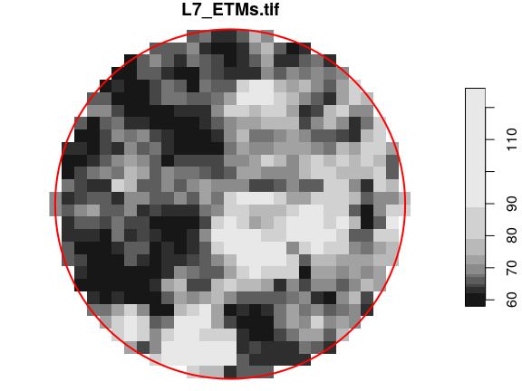

```r
circle = st_sfc(st_buffer(st_point(c(293749.5, 9115745)), 400), crs = st_crs(x))
plot(x[circle][, , , 1], reset = FALSE)
plot(circle, col = NA, border = 'red', add = TRUE, lwd = 2)
```

## Overviews

We can read rasters at a lower resolution when they contain so-called overviews. For this GeoTIFF file, they were created with the `gdaladdo` utility, in particular

```
gdaladdo -r average L7_ETMs.tif  2 4 8 16
```

which adds coarse resolution versions by using the *average* resampling method to compute values based on blocks of pixels. These can be read by

```r
x1 = read_stars(tif, options = c("OVERVIEW_LEVEL=1"))
x2 = read_stars(tif, options = c("OVERVIEW_LEVEL=2"))
x3 = read_stars(tif, options = c("OVERVIEW_LEVEL=3"))
dim(x1)
dim(x2)
dim(x3)
par(mfrow = c(1, 3), mar = rep(0.2, 4))
image(x1[,,,1])
image(x2[,,,1])
image(x3[,,,1])
```

[output not shown]

# Reading a raster time series: NetCDF

Another example is when we read raster time series model outputs in a NetCDF file, e.g. by

```r
system.file("nc/bcsd_obs_1999.nc", package = "stars") %>%
    read_stars("data/full_data_daily_2013.nc") -> w
## pr, tas,
```

We see that

```r
w
## stars object with 3 dimensions and 2 attributes
## attribute(s):
##    pr [mm/m]         tas [C]
##  Min.   :  0.59   Min.   :-0.421
##  1st Qu.: 56.14   1st Qu.: 8.899
##  Median : 81.88   Median :15.658
##  Mean   :101.26   Mean   :15.489
##  3rd Qu.:121.07   3rd Qu.:21.780
##  Max.   :848.55   Max.   :29.386
##  NA's   :7116     NA's   :7116
## dimension(s):
##      from to offset  delta  refsys point                    values
## x       1 81    -85  0.125      NA    NA                      NULL [x]
## y       1 33 37.125 -0.125      NA    NA                      NULL [y]
## time    1 12     NA     NA POSIXct    NA 1999-01-31,...,1999-12-31
```

For this dataset we can see that

- variables have units associated (and a wrong unit, `C` is assigned to temperature)
- time is now a dimension, with proper units and time steps

Alternatively, this dataset can be read using `read_ncdf`, as in

```r
system.file("nc/bcsd_obs_1999.nc", package = "stars") %>%
    read_ncdf()
## no 'var' specified, using pr, tas
## other available variables:
##  latitude, longitude, time
## No projection information found in nc file.
##  Coordinate variable units found to be degrees,
##  assuming WGS84 Lat/Lon.
## stars object with 3 dimensions and 2 attributes
## attribute(s):
##    pr [mm/m]         tas [C]
##  Min.   :  0.59   Min.   :-0.421
##  1st Qu.: 56.14   1st Qu.: 8.899
##  Median : 81.88   Median :15.658
##  Mean   :101.26   Mean   :15.489
##  3rd Qu.:121.07   3rd Qu.:21.780
##  Max.   :848.55   Max.   :29.386
##  NA's   :7116     NA's   :7116
## dimension(s):
##           from to offset delta  refsys point                    values
## longitude    1 81    -85 0.125  WGS 84    NA                      NULL [x]
## latitude     1 33     33 0.125  WGS 84    NA                      NULL [y]
## time         1 12     NA    NA POSIXct    NA 1999-01-31,...,1999-12-31
```

## Reading datasets from multiple files

Model data are often spread across many files. An example of a 0.25 degree grid, global daily sea surface temperature product is found here; a subset of the 1981 data was downloaded from here.

We read the data by giving `read_stars` a vector with character names:

```r
x = c(
"avhrr-only-v2.19810901.nc",
"avhrr-only-v2.19810902.nc",
"avhrr-only-v2.19810903.nc",
"avhrr-only-v2.19810904.nc",
"avhrr-only-v2.19810905.nc",
"avhrr-only-v2.19810906.nc",
"avhrr-only-v2.19810907.nc",
"avhrr-only-v2.19810908.nc",
"avhrr-only-v2.19810909.nc"
)
# see the second vignette:
# install.packages("starsdata", repos = "http://pebesma.staff.ifgi.de", type = "source")
file_list = system.file(paste0("netcdf/", x), package = "starsdata")
(y = read_stars(file_list, quiet = TRUE))
## stars object with 4 dimensions and 4 attributes
## attribute(s), summary of first 1e+05 cells:
##    sst [C*°]       anom [C*°]      err [C*°]     ice [percent]
##  Min.   :-1.80   Min.   :-4.69   Min.   :0.110   Min.   :0.010
##  1st Qu.:-1.19   1st Qu.:-0.06   1st Qu.:0.300   1st Qu.:0.730
##  Median :-1.05   Median : 0.52   Median :0.300   Median :0.830
##  Mean   :-0.32   Mean   : 0.23   Mean   :0.295   Mean   :0.766
##  3rd Qu.:-0.20   3rd Qu.: 0.71   3rd Qu.:0.300   3rd Qu.:0.870
##  Max.   : 9.36   Max.   : 3.70   Max.   :0.480   Max.   :1.000
##  NA's   :13360   NA's   :13360   NA's   :13360   NA's   :27377
## dimension(s):
##      from   to                   offset  delta  refsys point values
## x       1 1440                        0   0.25      NA    NA   NULL [x]
## y       1  720                       90  -0.25      NA    NA   NULL [y]
## zlev    1    1                    0 [m]     NA      NA    NA   NULL
## time    1    9 1981-09-01 02:00:00 CEST 1 days POSIXct    NA   NULL
```

Next, we select sea surface temperature (`sst`), and drop the singular `zlev` (depth) dimension using `adrop`:

```r
library(dplyr)
##
## Attaching package: 'dplyr'
## The following objects are masked from 'package:cubelyr':
##
##     as.tbl_cube, tbl_cube
## The following objects are masked from 'package:stats':
##
##     filter, lag
## The following objects are masked from 'package:base':
##
##     intersect, setdiff, setequal, union
library(abind)
z <- y %>% select(sst) %>% adrop()
```

We can now graph the sea surface temperature (SST) using `ggplot`, which needs data in a long table form, and without units:

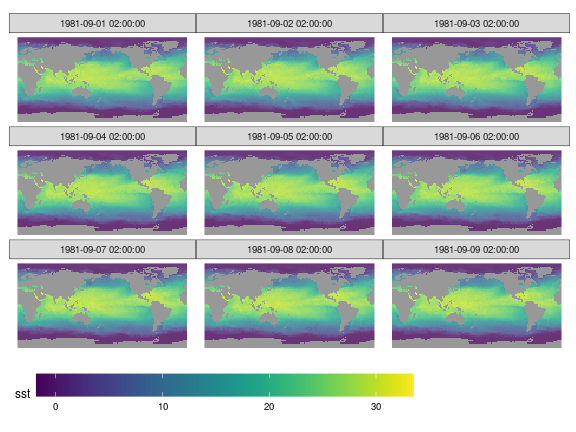

```r
library(ggplot2)
library(viridis)
## Loading required package: viridisLite
library(ggthemes)
ggplot() +
  geom_stars(data = z[1], alpha = 0.8, downsample = c(10, 10, 1)) +
  facet_wrap("time") +
  scale_fill_viridis() +
  coord_equal() +
  theme_map() +
  theme(legend.position = "bottom") +
  theme(legend.key.width = unit(2, "cm"))
```

# Writing stars objects to disk

We can write a stars object to disk by using `write_stars`; this used the GDAL write engine. Writing NetCDF files without going through the GDAL interface is currently not supported. `write_stars` currently writes only a single attribute:

```r
write_stars(adrop(y[1]), "sst.tif")
```

See the explanation of `merge` above to see how multiple attributes can be merged (folded) into a dimension.

# Cropping a raster’s extent

Using a curvilinear grid, taken from the example of `read_ncdf`:

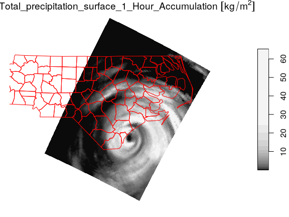

```r
prec_file = system.file("nc/test_stageiv_xyt.nc", package = "stars")
prec = read_ncdf(prec_file, curvilinear = c("lon", "lat"))
## no 'var' specified, using Total_precipitation_surface_1_Hour_Accumulation
## other available variables:
##  time_bounds, lon, lat, time
## No projection information found in nc file.
##  Coordinate variable units found to be degrees,
##  assuming WGS84 Lat/Lon.
## Warning in .get_nc_dimensions(dimensions, coord_var = all_coord_var, coords =
## coords, : bounds for time seem to be reversed; reverting them
##plot(prec) ## gives error about unique breaks
## remove NAs, zeros, and give a large number
## of breaks (used for validating in detail)
qu_0_omit = function(x, ..., n = 22) {
  if (inherits(x, "units"))
    x = units::drop_units(na.omit(x))
  c(0, quantile(x[x > 0], seq(0, 1, length.out = n)))
}
library(dplyr) # loads slice generic
prec_slice = slice(prec, index = 17, along = "time")
plot(prec_slice, border = NA, breaks = qu_0_omit(prec_slice[[1]]), reset = FALSE)
nc = sf::read_sf(system.file("gpkg/nc.gpkg", package = "sf"), "nc.gpkg")
plot(st_geometry(nc), add = TRUE, reset = FALSE, col = NA, border = 'red')
```

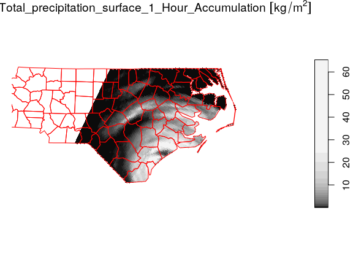

```r
nc = st_transform(nc, st_crs(prec_slice)) # datum transformation
plot(prec_slice[nc], border = NA, breaks = qu_0_omit(prec_slice[[1]]), reset = FALSE)
## although coordinates are longitude/latitude, st_intersects assumes that they are planar
plot(st_geometry(nc), add = TRUE, reset = FALSE, col = NA, border = 'red')
```

The selection `prec_slice[nc]` essentially calls `st_crop(prec_slice, nc)` to get a cropped selection. What happened here is that all cells not intersecting with North Carolina (sea) are set to `NA` values. For regular grids, the extent of the resulting `stars` object is also be reduced (cropped) by default; this can be controlled with the `crop` parameter to `st_crop` and `[.stars`.

# Vector data cube example

Like `tbl_cube`, `stars` arrays have no limits to the number of dimensions they handle. An example is the origin-destination (OD) matrix, by time and travel mode.

## OD: space x space x travel mode x time x time

We create a 5-dimensional matrix of traffic between regions, by day, by time of day, and by travel mode. Having day and time of day each as dimension is an advantage when we want to compute patterns over the day, for a certain period.

```r
nc = st_read(system.file("gpkg/nc.gpkg", package="sf"))
## Reading layer `nc.gpkg' from data source `/home/edzer/R/x86_64-pc-linux-gnu-library/3.6/sf/gpkg/nc.gpkg' using driver `GPKG'
## Simple feature collection with 100 features and 14 fields
## geometry type:  MULTIPOLYGON
## dimension:      XY
## bbox:           xmin: -84.32385 ymin: 33.88199 xmax: -75.45698 ymax: 36.58965
## geographic CRS: NAD27
to = from = st_geometry(nc) # 100 polygons: O and D regions
mode = c("car", "bike", "foot") # travel mode
day = 1:100 # arbitrary
library(units)
## udunits system database from /usr/share/xml/udunits
units(day) = as_units("days since 2015-01-01")
hour = set_units(0:23, h) # hour of day
dims = st_dimensions(origin = from, destination = to, mode = mode, day = day, hour = hour)
(n = dim(dims))
##      origin destination        mode         day        hour
##         100         100           3         100          24
traffic = array(rpois(prod(n), 10), dim = n) # simulated traffic counts
(st = st_as_stars(list(traffic = traffic),  dimensions = dims))
## stars object with 5 dimensions and 1 attribute
## attribute(s), summary of first 1e+05 cells:
##     traffic
##  Min.   : 0.000
##  1st Qu.: 8.000
##  Median :10.000
##  Mean   : 9.989
##  3rd Qu.:12.000
##  Max.   :27.000
## dimension(s):
##             from  to                      offset                       delta
## origin         1 100                          NA                          NA
## destination    1 100                          NA                          NA
## mode           1   3                          NA                          NA
## day            1 100 1 [(days since 2015-01-01)] 1 [(days since 2015-01-01)]
## hour           1  24                       0 [h]                       1 [h]
##              refsys point
## origin        NAD27 FALSE
## destination   NAD27 FALSE
## mode             NA FALSE
## day         udunits FALSE
## hour        udunits FALSE
##                                                                        values
## origin      MULTIPOLYGON (((-81.47276 3...,...,MULTIPOLYGON (((-78.65572 3...
## destination MULTIPOLYGON (((-81.47276 3...,...,MULTIPOLYGON (((-78.65572 3...
## mode                                                             car,...,foot
## day                                                                      NULL
## hour                                                                     NULL
```

This array contains the simple feature geometries of origin and destination so that we can directly plot every slice without additional table joins. If we want to represent such an array as a `tbl_cube`, the simple feature geometry dimensions need to be replaced by indexes:

```r
st %>% as.tbl_cube()
## Source: local array [72,000,000 x 5]
## D: origin [int, 100]
## D: destination [int, 100]
## D: mode [chr, 3]
## D: day [[(days since 2015-01-01)], 100]
## D: hour [[h], 24]
## M: traffic [int[,100,3,100,24]]
```

The following demonstrates how `dplyr` can filter bike travel, and compute mean bike traffic by hour of day:

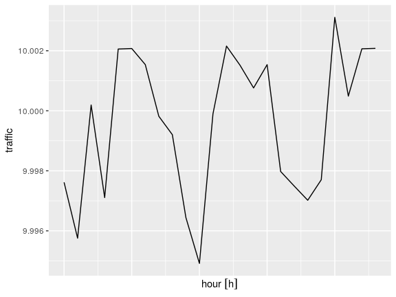

```r
b <- st %>%
  as.tbl_cube() %>%
  filter(mode == "bike") %>%
  group_by(hour) %>%
  summarise(traffic = mean(traffic)) %>%
  as.data.frame()
require(ggforce) # for plotting a units variable
## Loading required package: ggforce
ggplot() +
  geom_line(data = b, aes(x = hour, y = traffic))
```